# Report for merinov_gosl

## 1. The Data

Here is your dataset as we reprocessed it. Please take a look.

**Click to see the clean data**

```r
#
 study_data |>
          kable( format = "html") %>%
          kable_styling(position = "center", full_width = F, bootstrap_options = c("striped","hover"))%>%
          scroll_box( width = "1000px", height = "500px", fixed_thead = T)
```

| Entry | Study | Region | Site | Depth.m | Sample.Year | Sample.Month | Sample.Day | Latitude | Longitude | Taxon | Fixed.or.Random | Sample.Unit.Size.sq.m | Percent.Cover | Stipe.Density.num.per.sq.m | Individual.Density.num.per.sq.m | Biomass.kg.wet.per.sq.m |
| --- | --- | --- | --- | --- | --- | --- | --- | --- | --- | --- | --- | --- | --- | --- | --- | --- |
| 1 | merinov_gosl | Gulf of Saint Lawrence | BAG | NA | 2012 | 8 | 28 | 48.7743 | -68.9702 | Ascophyllum nodosum | Random | NA | NA | 4.000000 | 4.000000 | 1.0100000 |
| 2 | merinov_gosl | Gulf of Saint Lawrence | BAG | NA | 2012 | 8 | 28 | 48.7743 | -68.9702 | Fucus distichus subsp. edentatus | Random | NA | NA | NA | NA | 0.0000000 |
| 3 | merinov_gosl | Gulf of Saint Lawrence | BAG | NA | 2012 | 8 | 28 | 48.7743 | -68.9702 | Fucus distichus subsp. evanescens | Random | NA | NA | 3.000000 | 3.000000 | 0.4000000 |
| 4 | merinov_gosl | Gulf of Saint Lawrence | BAG | NA | 2012 | 8 | 28 | 48.7743 | -68.9702 | Fucus vesiculosus | Random | NA | NA | NA | NA | 0.0000000 |
| 5 | merinov_gosl | Gulf of Saint Lawrence | BAG | NA | 2012 | 8 | 28 | 48.7743 | -68.9695 | Ascophyllum nodosum | Random | NA | NA | NA | NA | 0.0000000 |
| 6 | merinov_gosl | Gulf of Saint Lawrence | BAG | NA | 2012 | 8 | 28 | 48.7743 | -68.9695 | Fucus distichus subsp. edentatus | Random | NA | NA | NA | NA | 0.0000000 |
| 7 | merinov_gosl | Gulf of Saint Lawrence | BAG | NA | 2012 | 8 | 28 | 48.7743 | -68.9695 | Fucus distichus subsp. evanescens | Random | NA | NA | NA | NA | 0.0000000 |
| 8 | merinov_gosl | Gulf of Saint Lawrence | BAG | NA | 2012 | 8 | 28 | 48.7743 | -68.9695 | Fucus vesiculosus | Random | NA | NA | NA | NA | 0.0000000 |
| 9 | merinov_gosl | Gulf of Saint Lawrence | BAG | NA | 2012 | 8 | 28 | 48.7743 | -68.9688 | Ascophyllum nodosum | Random | NA | NA | NA | NA | 0.0000000 |
| 10 | merinov_gosl | Gulf of Saint Lawrence | BAG | NA | 2012 | 8 | 28 | 48.7743 | -68.9688 | Fucus distichus subsp. edentatus | Random | NA | NA | NA | NA | 0.0000000 |
| 11 | merinov_gosl | Gulf of Saint Lawrence | BAG | NA | 2012 | 8 | 28 | 48.7743 | -68.9688 | Fucus distichus subsp. evanescens | Random | NA | NA | NA | NA | 0.0000000 |
| 12 | merinov_gosl | Gulf of Saint Lawrence | BAG | NA | 2012 | 8 | 28 | 48.7743 | -68.9688 | Fucus vesiculosus | Random | NA | NA | 3.000000 | 3.000000 | 0.1800000 |
| 13 | merinov_gosl | Gulf of Saint Lawrence | BAG | NA | 2012 | 8 | 28 | 48.7743 | -68.9682 | Ascophyllum nodosum | Random | NA | NA | 6.000000 | 6.000000 | 1.5400000 |
| 14 | merinov_gosl | Gulf of Saint Lawrence | BAG | NA | 2012 | 8 | 28 | 48.7743 | -68.9682 | Fucus distichus subsp. edentatus | Random | NA | NA | NA | NA | 0.0000000 |
| 15 | merinov_gosl | Gulf of Saint Lawrence | BAG | NA | 2012 | 8 | 28 | 48.7743 | -68.9682 | Fucus distichus subsp. evanescens | Random | NA | NA | 6.000000 | 6.000000 | 0.4500000 |
| 16 | merinov_gosl | Gulf of Saint Lawrence | BAG | NA | 2012 | 8 | 28 | 48.7743 | -68.9682 | Fucus vesiculosus | Random | NA | NA | NA | NA | 0.0000000 |
| 17 | merinov_gosl | Gulf of Saint Lawrence | BAG | NA | 2012 | 8 | 28 | 48.7743 | -68.9675 | Ascophyllum nodosum | Random | NA | NA | 10.000000 | 10.000000 | 2.8400000 |
| 18 | merinov_gosl | Gulf of Saint Lawrence | BAG | NA | 2012 | 8 | 28 | 48.7743 | -68.9675 | Fucus distichus subsp. edentatus | Random | NA | NA | NA | NA | 0.0000000 |
| 19 | merinov_gosl | Gulf of Saint Lawrence | BAG | NA | 2012 | 8 | 28 | 48.7743 | -68.9675 | Fucus distichus subsp. evanescens | Random | NA | NA | 12.000000 | 12.000000 | 0.2000000 |
| 20 | merinov_gosl | Gulf of Saint Lawrence | BAG | NA | 2012 | 8 | 28 | 48.7743 | -68.9675 | Fucus vesiculosus | Random | NA | NA | 37.000000 | 37.000000 | 1.2900000 |
| 21 | merinov_gosl | Gulf of Saint Lawrence | BAG | NA | 2012 | 8 | 28 | 48.7743 | -68.9668 | Ascophyllum nodosum | Random | NA | NA | 1.000000 | 1.000000 | 0.4500000 |
| 22 | merinov_gosl | Gulf of Saint Lawrence | BAG | NA | 2012 | 8 | 28 | 48.7743 | -68.9668 | Fucus distichus subsp. edentatus | Random | NA | NA | 24.000000 | 24.000000 | 2.8900000 |
| 23 | merinov_gosl | Gulf of Saint Lawrence | BAG | NA | 2012 | 8 | 28 | 48.7743 | -68.9668 | Fucus distichus subsp. evanescens | Random | NA | NA | 56.000000 | 56.000000 | 2.6400000 |
| 24 | merinov_gosl | Gulf of Saint Lawrence | BAG | NA | 2012 | 8 | 28 | 48.7743 | -68.9668 | Fucus vesiculosus | Random | NA | NA | 22.000000 | 22.000000 | 1.0100000 |
| 25 | merinov_gosl | Gulf of Saint Lawrence | BAG | NA | 2012 | 8 | 28 | 48.7788 | -68.9621 | Ascophyllum nodosum | Random | NA | NA | 24.000000 | 24.000000 | 1.5800000 |
| 26 | merinov_gosl | Gulf of Saint Lawrence | BAG | NA | 2012 | 8 | 28 | 48.7788 | -68.9621 | Fucus distichus subsp. edentatus | Random | NA | NA | NA | NA | 0.0000000 |
| 27 | merinov_gosl | Gulf of Saint Lawrence | BAG | NA | 2012 | 8 | 28 | 48.7788 | -68.9621 | Fucus distichus subsp. evanescens | Random | NA | NA | NA | NA | 0.0000000 |
| 28 | merinov_gosl | Gulf of Saint Lawrence | BAG | NA | 2012 | 8 | 28 | 48.7788 | -68.9621 | Fucus vesiculosus | Random | NA | NA | 10.000000 | 10.000000 | 1.0800000 |
| 29 | merinov_gosl | Gulf of Saint Lawrence | BAG | NA | 2012 | 8 | 28 | 48.7788 | -68.9615 | Ascophyllum nodosum | Random | NA | NA | NA | NA | 0.0000000 |
| 30 | merinov_gosl | Gulf of Saint Lawrence | BAG | NA | 2012 | 8 | 28 | 48.7788 | -68.9615 | Fucus distichus subsp. edentatus | Random | NA | NA | NA | NA | 0.0000000 |

[output cut: 7003 more lines]

Here is your dataset as where we have now summed across all kelp species and put into the KelpTime main database format.

**Click to see the data in kelptime format**

```r
#|
kelptime_study |>
         kable( format = "html") %>%
         kable_styling(position = "center", full_width = F, bootstrap_options = c("striped","hover"))%>%
         scroll_box( width = "1000px", height = "500px", fixed_thead = T)
```

| study | site | period | latitude | longitude | sample_unit_size_sq_m | sasdate | max_depth | mean_depth | min_depth | biomass_kg_wet_per_sq_m | stipe_density_num_per_sq_m | individual_density_num_per_sq_m | percent_cover | has_bm | has_sd | has_id | has_pc | use_which | focalKelp | focalUnit | geometry | ecoregion | province | realm | focal_std_by_ecoregion | focal_std_by_province | focal_std_by_realm | ln_focal_std_by_ecoregion | ln_focal_std_by_province | … |
| --- | --- | --- | --- | --- | --- | --- | --- | --- | --- | --- | --- | --- | --- | --- | --- | --- | --- | --- | --- | --- | --- | --- | --- | --- | --- | --- | --- | --- | --- | --- |
| merinov_gosl | MSM | 1 | 48.68300 | -67.9764 | 9999 | 2009-07-25 | 9999 | 9999 | 9999 | NA | NA | NA | 89.00000 | 86 | 38 | 38 | 104 | 4 | 89.00000 | Percent cover | c(-67.9764, 48.683) | Gulf of St. Lawrence - Eastern Scotian Shelf | Cold Temperate Northwest Atlantic | Temperate Northern Atlantic | 0.8002569 | 0.3571169 | 0.3571169 | -0.2104039 | -1.0020749 | … |
| merinov_gosl | MSM | 2 | 48.68300 | -67.9764 | 9999 | 2009-07-26 | 9999 | 9999 | 9999 | NA | NA | NA | 94.50000 | 86 | 38 | 38 | 104 | 4 | 94.50000 | Percent cover | c(-67.9764, 48.683) | Gulf of St. Lawrence - Eastern Scotian Shelf | Cold Temperate Northwest Atlantic | Temperate Northern Atlantic | 0.8497110 | 0.3791859 | 0.3791859 | -0.1511590 | -0.9436981 | … |
| merinov_gosl | MSM | 3 | 48.68300 | -67.9764 | 9999 | 2009-07-27 | 9999 | 9999 | 9999 | NA | NA | NA | 85.00000 | 86 | 38 | 38 | 104 | 4 | 85.00000 | Percent cover | c(-67.9764, 48.683) | Gulf of St. Lawrence - Eastern Scotian Shelf | Cold Temperate Northwest Atlantic | Temperate Northern Atlantic | 0.7642903 | 0.3410667 | 0.3410667 | -0.2558084 | -1.0467790 | … |
| merinov_gosl | MSM | 4 | 48.68300 | -67.9764 | 9999 | 2009-07-28 | 9999 | 9999 | 9999 | NA | NA | NA | 97.00000 | 86 | 38 | 38 | 104 | 4 | 97.00000 | Percent cover | c(-67.9764, 48.683) | Gulf of St. Lawrence - Eastern Scotian Shelf | Cold Temperate Northwest Atlantic | Temperate Northern Atlantic | 0.8721901 | 0.3892173 | 0.3892173 | -0.1253477 | -0.9182494 | … |
| merinov_gosl | MSM | 5 | 48.68300 | -67.9764 | 9999 | 2010-05-15 | 9999 | 9999 | 9999 | NA | NA | NA | 62.00000 | 86 | 38 | 38 | 104 | 4 | 62.00000 | Percent cover | c(-67.9764, 48.683) | Gulf of St. Lawrence - Eastern Scotian Shelf | Cold Temperate Northwest Atlantic | Temperate Northern Atlantic | 0.5574823 | 0.2487781 | 0.2487781 | -0.5665457 | -1.3517844 | … |
| merinov_gosl | MSM | 6 | 48.68300 | -67.9764 | 9999 | 2010-05-16 | 9999 | 9999 | 9999 | NA | NA | NA | 71.33333 | 86 | 38 | 38 | 104 | 4 | 71.33333 | Percent cover | c(-67.9764, 48.683) | Gulf of St. Lawrence - Eastern Scotian Shelf | Cold Temperate Northwest Atlantic | Temperate Northern Atlantic | 0.6414044 | 0.2862285 | 0.2862285 | -0.4286246 | -1.2166240 | … |
| merinov_gosl | MSM | 7 | 48.68300 | -67.9764 | 9999 | 2010-07-15 | 9999 | 9999 | 9999 | NA | NA | NA | 99.00000 | 86 | 38 | 38 | 104 | 4 | 99.00000 | Percent cover | c(-67.9764, 48.683) | Gulf of St. Lawrence - Eastern Scotian Shelf | Cold Temperate Northwest Atlantic | Temperate Northern Atlantic | 0.8901734 | 0.3972424 | 0.3972424 | -0.1051679 | -0.8983467 | … |
| merinov_gosl | MSM | 8 | 48.68300 | -67.9764 | 9999 | 2010-07-16 | 9999 | 9999 | 9999 | NA | NA | NA | 99.66667 | 86 | 38 | 38 | 104 | 4 | 99.66667 | Percent cover | c(-67.9764, 48.683) | Gulf of St. Lawrence - Eastern Scotian Shelf | Cold Temperate Northwest Atlantic | Temperate Northern Atlantic | 0.8961678 | 0.3999174 | 0.3999174 | -0.0985307 | -0.8917995 | … |
| merinov_gosl | MSM | 9 | 48.68300 | -67.9764 | 9999 | 2010-09-10 | 9999 | 9999 | 9999 | NA | NA | NA | 89.14286 | 86 | 38 | 38 | 104 | 4 | 89.14286 | Percent cover | c(-67.9764, 48.683) | Gulf of St. Lawrence - Eastern Scotian Shelf | Cold Temperate Northwest Atlantic | Temperate Northern Atlantic | 0.8015414 | 0.3576901 | 0.3576901 | -0.2088198 | -1.0005147 | … |
| merinov_gosl | MSM | 10 | 48.68300 | -67.9764 | 9999 | 2010-09-11 | 9999 | 9999 | 9999 | NA | NA | NA | 98.00000 | 86 | 38 | 38 | 104 | 4 | 98.00000 | Percent cover | c(-67.9764, 48.683) | Gulf of St. Lawrence - Eastern Scotian Shelf | Cold Temperate Northwest Atlantic | Temperate Northern Atlantic | 0.8811818 | 0.3932299 | 0.3932299 | -0.1152069 | -0.9082485 | … |
| merinov_gosl | MSM | 11 | 48.65575 | -68.0876 | 9999 | 2011-05-15 | 9999 | 9999 | 9999 | NA | NA | NA | 2.62500 | 86 | 38 | 38 | 104 | 4 | 2.62500 | Percent cover | c(-68.0876, 48.65575) | Gulf of St. Lawrence - Eastern Scotian Shelf | Cold Temperate Northwest Atlantic | Temperate Northern Atlantic | 0.0236031 | 0.0105329 | 0.0105329 | -3.3931375 | -3.8857247 | … |
| merinov_gosl | MSM | 12 | 48.68300 | -67.9764 | 9999 | 2011-05-19 | 9999 | 9999 | 9999 | NA | NA | NA | 26.00000 | 86 | 38 | 38 | 104 | 4 | 26.00000 | Percent cover | c(-67.9764, 48.683) | Gulf of St. Lawrence - Eastern Scotian Shelf | Cold Temperate Northwest Atlantic | Temperate Northern Atlantic | 0.2337829 | 0.1043263 | 0.1043263 | -1.4114771 | -2.1686987 | … |
| merinov_gosl | MSM | 13 | 48.68300 | -67.9764 | 9999 | 2011-08-04 | 9999 | 9999 | 9999 | NA | NA | NA | 59.40000 | 86 | 38 | 38 | 104 | 4 | 59.40000 | Percent cover | c(-67.9764, 48.683) | Gulf of St. Lawrence - Eastern Scotian Shelf | Cold Temperate Northwest Atlantic | Temperate Northern Atlantic | 0.5341040 | 0.2383454 | 0.2383454 | -0.6086148 | -1.3929346 | … |
| merinov_gosl | MSM | 14 | 48.68300 | -67.9764 | 9999 | 2011-09-29 | 9999 | 9999 | 9999 | NA | NA | NA | 92.90000 | 86 | 38 | 38 | 104 | 4 | 92.90000 | Percent cover | c(-67.9764, 48.683) | Gulf of St. Lawrence - Eastern Scotian Shelf | Cold Temperate Northwest Atlantic | Temperate Northern Atlantic | 0.8353243 | 0.3727659 | 0.3727659 | -0.1680349 | -0.9603318 | … |
| merinov_gosl | MSM | 15 | 48.68300 | -67.9764 | 9999 | 2012-05-09 | 9999 | 9999 | 9999 | NA | NA | NA | 23.10000 | 86 | 38 | 38 | 104 | 4 | 23.10000 | Percent cover | c(-67.9764, 48.683) | Gulf of St. Lawrence - Eastern Scotian Shelf | Cold Temperate Northwest Atlantic | Temperate Northern Atlantic | 0.2077071 | 0.0926899 | 0.0926899 | -1.5246046 | -2.2760416 | … |
| merinov_gosl | MSM | 16 | 48.68300 | -67.9764 | 9999 | 2012-07-07 | 9999 | 9999 | 9999 | NA | NA | NA | 71.60000 | 86 | 38 | 38 | 104 | 4 | 71.60000 | Percent cover | c(-67.9764, 48.683) | Gulf of St. Lawrence - Eastern Scotian Shelf | Cold Temperate Northwest Atlantic | Temperate Northern Atlantic | 0.6438022 | 0.2872985 | 0.2872985 | -0.4249504 | -1.2130184 | … |
| merinov_gosl | MSM | 17 | 48.68300 | -67.9764 | 9999 | 2012-09-07 | 9999 | 9999 | 9999 | NA | NA | NA | 95.20000 | 86 | 38 | 38 | 104 | 4 | 95.20000 | Percent cover | c(-67.9764, 48.683) | Gulf of St. Lawrence - Eastern Scotian Shelf | Cold Temperate Northwest Atlantic | Temperate Northern Atlantic | 0.8560051 | 0.3819947 | 0.3819947 | -0.1438644 | -0.9365069 | … |
| merinov_gosl | MSM | 18 | 48.68300 | -67.9764 | 9999 | 2012-09-18 | 9999 | 9999 | 9999 | NA | NA | NA | 99.50000 | 86 | 38 | 38 | 104 | 4 | 99.50000 | Percent cover | c(-67.9764, 48.683) | Gulf of St. Lawrence - Eastern Scotian Shelf | Cold Temperate Northwest Atlantic | Temperate Northern Atlantic | 0.8946692 | 0.3992487 | 0.3992487 | -0.1001859 | -0.8934323 | … |
| merinov_gosl | PG | 1 | 48.37340 | -69.3669 | 9999 | 2009-05-27 | 9999 | 9999 | 9999 | NA | NA | NA | 86.50000 | 86 | 38 | 38 | 104 | 4 | 86.50000 | Percent cover | c(-69.3669, 48.3734) | Gulf of St. Lawrence - Eastern Scotian Shelf | Cold Temperate Northwest Atlantic | Temperate Northern Atlantic | 0.7777778 | 0.3470855 | 0.3470855 | -0.2385392 | -1.0297799 | … |
| merinov_gosl | PG | 2 | 48.37340 | -69.3669 | 9999 | 2009-05-28 | 9999 | 9999 | 9999 | NA | NA | NA | 95.00000 | 86 | 38 | 38 | 104 | 4 | 95.00000 | Percent cover | c(-69.3669, 48.3734) | Gulf of St. Lawrence - Eastern Scotian Shelf | Cold Temperate Northwest Atlantic | Temperate Northern Atlantic | 0.8542068 | 0.3811922 | 0.3811922 | -0.1459432 | -0.9385563 | … |
| merinov_gosl | PG | 3 | 48.37340 | -69.3669 | 9999 | 2009-08-21 | 9999 | 9999 | 9999 | NA | NA | NA | 99.40000 | 86 | 38 | 38 | 104 | 4 | 99.40000 | Percent cover | c(-69.3669, 48.3734) | Gulf of St. Lawrence - Eastern Scotian Shelf | Cold Temperate Northwest Atlantic | Temperate Northern Atlantic | 0.8937701 | 0.3988474 | 0.3988474 | -0.1011803 | -0.8944132 | … |
| merinov_gosl | PG | 4 | 48.37340 | -69.3669 | 9999 | 2010-05-15 | 9999 | 9999 | 9999 | NA | NA | NA | 96.83333 | 86 | 38 | 38 | 104 | 4 | 96.83333 | Percent cover | c(-69.3669, 48.3734) | Gulf of St. Lawrence - Eastern Scotian Shelf | Cold Temperate Northwest Atlantic | Temperate Northern Atlantic | 0.8706915 | 0.3885486 | 0.3885486 | -0.1270479 | -0.9199260 | … |
| merinov_gosl | PG | 5 | 48.37340 | -69.3669 | 9999 | 2010-05-16 | 9999 | 9999 | 9999 | NA | NA | NA | 100.00000 | 86 | 38 | 38 | 104 | 4 | 100.00000 | Percent cover | c(-69.3669, 48.3734) | Gulf of St. Lawrence - Eastern Scotian Shelf | Cold Temperate Northwest Atlantic | Temperate Northern Atlantic | 0.8991651 | 0.4012550 | 0.4012550 | -0.0952286 | -0.8885419 | … |
| merinov_gosl | PG | 6 | 48.37340 | -69.3669 | 9999 | 2010-05-18 | 9999 | 9999 | 9999 | NA | NA | NA | 101.12500 | 86 | 38 | 38 | 104 | 4 | 101.12500 | Percent cover | c(-69.3669, 48.3734) | Gulf of St. Lawrence - Eastern Scotian Shelf | Cold Temperate Northwest Atlantic | Temperate Northern Atlantic | 0.9092807 | 0.4057691 | 0.4057691 | -0.0841638 | -0.8776253 | … |
| merinov_gosl | PG | 7 | 48.37340 | -69.3669 | 9999 | 2010-07-27 | 9999 | 9999 | 9999 | NA | NA | NA | 105.00000 | 86 | 38 | 38 | 104 | 4 | 105.00000 | Percent cover | c(-69.3669, 48.3734) | Gulf of St. Lawrence - Eastern Scotian Shelf | Cold Temperate Northwest Atlantic | Temperate Northern Atlantic | 0.9441233 | 0.4213177 | 0.4213177 | -0.0469624 | -0.8409103 | … |
| merinov_gosl | PG | 8 | 48.37340 | -69.3669 | 9999 | 2010-07-28 | 9999 | 9999 | 9999 | NA | NA | NA | 98.66667 | 86 | 38 | 38 | 104 | 4 | 98.66667 | Percent cover | c(-69.3669, 48.3734) | Gulf of St. Lawrence - Eastern Scotian Shelf | Cold Temperate Northwest Atlantic | Temperate Northern Atlantic | 0.8871762 | 0.3959049 | 0.3959049 | -0.1085030 | -0.9016364 | … |
| merinov_gosl | PG | 9 | 48.37340 | -69.3669 | 9999 | 2010-07-29 | 9999 | 9999 | 9999 | NA | NA | NA | 75.00000 | 86 | 38 | 38 | 104 | 4 | 75.00000 | Percent cover | c(-69.3669, 48.3734) | Gulf of St. Lawrence - Eastern Scotian Shelf | Cold Temperate Northwest Atlantic | Temperate Northern Atlantic | 0.6743738 | 0.3009412 | 0.3009412 | -0.3792510 | -1.1681514 | … |
| merinov_gosl | PG | 10 | 48.37340 | -69.3669 | 9999 | 2010-08-08 | 9999 | 9999 | 9999 | NA | NA | NA | 62.00000 | 86 | 38 | 38 | 104 | 4 | 62.00000 | Percent cover | c(-69.3669, 48.3734) | Gulf of St. Lawrence - Eastern Scotian Shelf | Cold Temperate Northwest Atlantic | Temperate Northern Atlantic | 0.5574823 | 0.2487781 | 0.2487781 | -0.5665457 | -1.3517844 | … |
| merinov_gosl | PG | 11 | 48.37340 | -69.3669 | 9999 | 2010-08-09 | 9999 | 9999 | 9999 | NA | NA | NA | 76.00000 | 86 | 38 | 38 | 104 | 4 | 76.00000 | Percent cover | c(-69.3669, 48.3734) | Gulf of St. Lawrence - Eastern Scotian Shelf | Cold Temperate Northwest Atlantic | Temperate Northern Atlantic | 0.6833654 | 0.3049538 | 0.3049538 | -0.3661981 | -1.1553294 | … |
| merinov_gosl | PG | 12 | 48.37340 | -69.3669 | 9999 | 2010-08-10 | 9999 | 9999 | 9999 | NA | NA | NA | 100.00000 | 86 | 38 | 38 | 104 | 4 | 100.00000 | Percent cover | c(-69.3669, 48.3734) | Gulf of St. Lawrence - Eastern Scotian Shelf | Cold Temperate Northwest Atlantic | Temperate Northern Atlantic | 0.8991651 | 0.4012550 | 0.4012550 | -0.0952286 | -0.8885419 | … |

[output cut: 74 more lines]

## 2. Plots of raw data

### 2.1 By metric

Here is what your data looks like with all sites plotted together looking at each sampling metric.

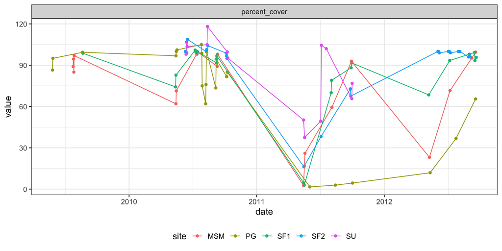

```r
kelptime_study_measurement_long <-
  kelptime_study |>
  tidyr::pivot_longer(cols =biomass_kg_wet_per_sq_m:percent_cover) |>
  filter(!is.na(value))

ggplot(kelptime_study_measurement_long,
       aes(x = date, y = value,
           color = site)) +
  geom_point() +
  geom_line() +
  facet_wrap(vars(name), scale = "free_y")
```

### 2.2 Standardized data

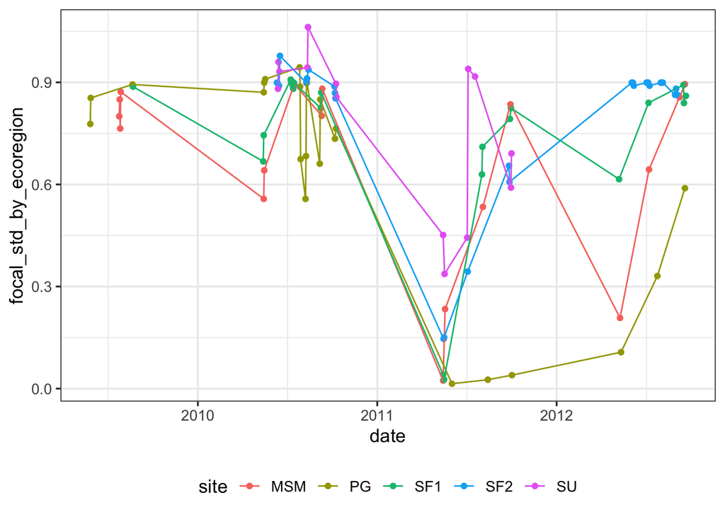

```r
ggplot(kelptime_study,
       aes(x = date, y = focal_std_by_ecoregion,
           color = site)) +
  geom_point() +
  geom_line()
```

### 2.3 Standardized data by site

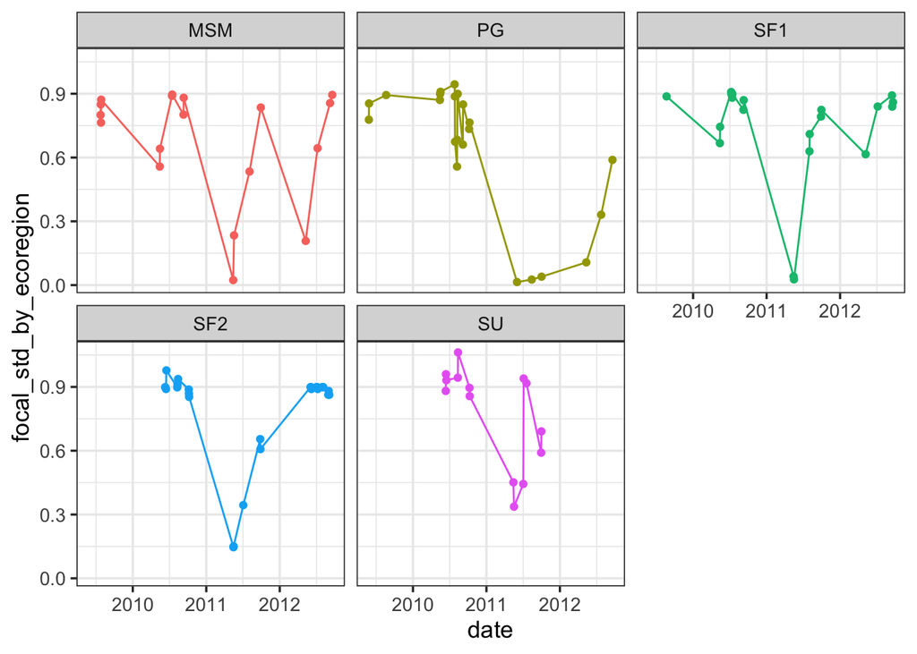

```r
ggplot(kelptime_study,
       aes(x = date, y = focal_std_by_ecoregion,
           color = site)) +
  geom_point() +
  geom_line() +
  facet_wrap(vars(site)) +
  guides(color = "none")
```

## 3. Modeled timeseries resuls

We fit two models. One where the slope varies by ecoregion (note: the GOSL and Newfoundland are collapsed) and one where the slope does not vary by ecoregion. Based on the modeled results, here is the smoothed fits to your data. Note - thus far, the model with a common slope appears to be the correct is the one with a common slope (best fit in terms of prediction and p-value for slope*ecoregion is not distinguishable from 0).

**Note** - the study (black) line might not line up in the middle or on trajectories, as it is shrunken in towards the grand mean for the ecoregion.

### 3.1 Slope Varying by Ecoregion Model

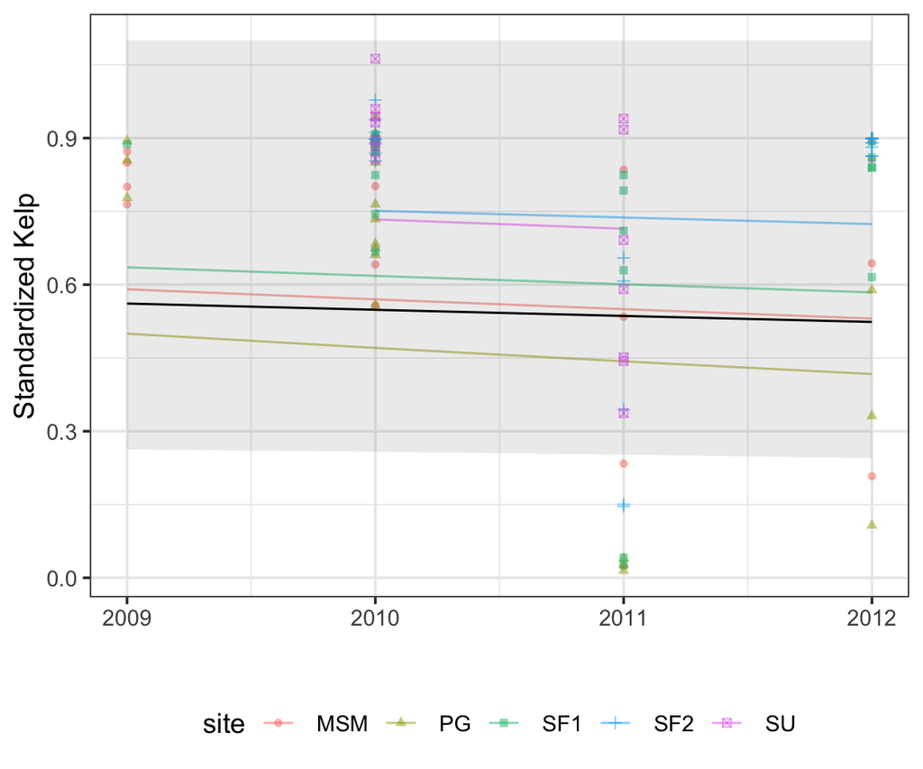

```r
mod_ecoregion <- readRDS("models/mod_ecoregion.rds")


# for plotting to do the back transform
exp_trans <- function(dat){

  dat |>
    mutate(
      Predicted = exp(Predicted)-0.01,
           CI_low = exp(CI_low)-0.01,
           CI_high = exp(CI_high)-0.01,
           CI_high = ifelse(CI_high>1.1, 1.1, CI_high)
    )|>
               mutate(trajectory =
                        gsub(study[1], "", trajectory))

}


re_ecoregion <- ranef(mod_ecoregion)$cond$study |>
  as_tibble(rownames = "study")  |>
  filter(study == params$study) |>
  pull(`(Intercept)`)


dat_fixed_ecoregion <- estimate_relation(mod_ecoregion,
                               include_random = FALSE,
                  length = 200,
                  data = kelptime_study) |>
  mutate(Predicted = Predicted + re_ecoregion,
         CI_high = CI_high + re_ecoregion,
         CI_low = CI_low + re_ecoregion) |>
  exp_trans()

dat_traj_ecoregion <- estimate_relation(mod_ecoregion,
                              include_random = TRUE,
                  length = 200,
                  data = kelptime_study) |>
    exp_trans()


ggplot(dat_traj_ecoregion, aes(x = year)) +
  geom_line(aes(y = Predicted,
                color = trajectory), alpha = 0.5) +
  geom_point(aes(y = focal_std_by_ecoregion,
                 group = trajectory,
                 shape = trajectory,
                 color = trajectory), alpha = 0.5,
             data = kelptime_study |>
               mutate(trajectory =
                        gsub(study[1], "", trajectory))) +
  geom_line(data = dat_fixed_ecoregion,
            aes(y = Predicted), color = "black") +
  geom_ribbon(data = dat_fixed_ecoregion,
            aes(y = Predicted,
                ymin = CI_low,
                ymax = CI_high), color = NA,
            alpha = 0.1) +
  labs(x = "", y = "Standardized Kelp",
      color = "site", shape = "site")
```

### 3.2 Common Slope Model

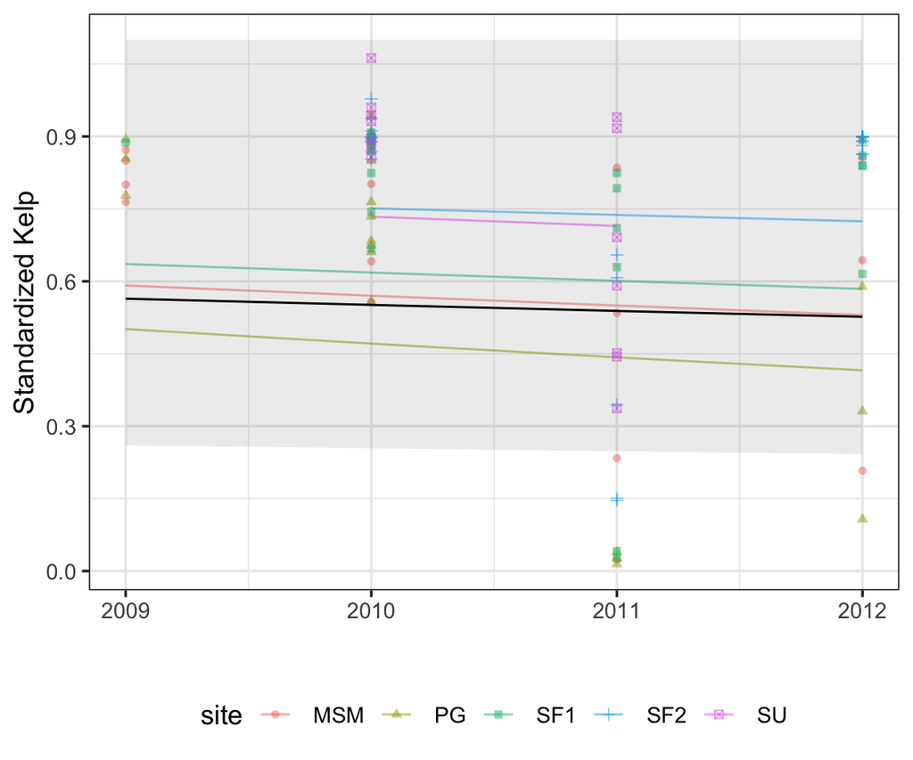

```r
mod_common_slope <- readRDS("models/mod_common_slope.rds")

re <- ranef(mod_common_slope)$cond$study |>
  as_tibble(rownames = "study")  |>
  filter(study == params$study) |>
  pull(`(Intercept)`)


dat_fixed <- estimate_relation(mod_common_slope,
                               include_random = FALSE,
                  length = 200,
                  data = kelptime_study) |>
  mutate(Predicted = Predicted + re,
         CI_high = CI_high + re_ecoregion,
         CI_low = CI_low + re_ecoregion) |>
  exp_trans()

dat_traj <- estimate_relation(mod_common_slope,
                              include_random = TRUE,
                  length = 200,
                  data = kelptime_study) |>
    exp_trans()

ggplot(dat_traj, aes(x = year)) +
  geom_line(aes(y = Predicted,
                color = trajectory), alpha = 0.5) +
  geom_point(aes(y = focal_std_by_ecoregion,
                 group = trajectory,
                 shape = trajectory,
                 color = trajectory), alpha = 0.5,
             data = kelptime_study |>
               mutate(trajectory =
                        gsub(study[1], "", trajectory))) +
  geom_line(data = dat_fixed,
            aes(y = Predicted), color = "black") +
  geom_ribbon(data = dat_fixed,
            aes(y = Predicted,
                ymin = CI_low,
                ymax = CI_high), color = NA,
            alpha = 0.1) +
  labs(x = "", y = "Standardized Kelp",
      color = "site", shape = "site")
```